# Genetic Evaluation - Notebook 1

Peter von Rohr

2021-04-16

## Problem 1: Breeding Programs

What are the components of a breeding program. Insert the components into the following diagram.

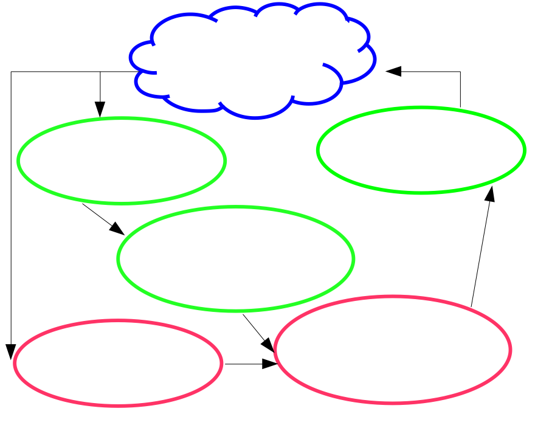

### Your Solution

Fill out the above shown diagram with the components of a breeding program.

## Problem 2: Performance Test

$$B = \frac{n}{n+k}$$
where $n$ stands for the number of daughters and $k$ corresponds to the term $(4-h^2)/h^2$. The variable $h^2$ is the heritability of the trait under investigation. For our example we assume that $h^2 = 0.25$.

### Your Task

- Compute the number of daugthers $n$ that must be tested for a given sire such that $B$ is at least $0.5$.
- How long does it take from the birth of a given sire to the time point where the predicted breeding value of the bull with a reliability of $B$ of at least $0.5$ is available? Here we assume that the first semen can be harvested from the bull at an age of $12$ months and the average age at first calving is $27$ months.

### Your Solution

For the first task, start by computing the value of $k$ for the given heritability $h^2$. Then solve the above equation for the number of daughters $n$ and insert the given numbers for $B$ and the computed value of $k$.

*Latest Changes: 2021-04-18 14:32:13 (peter)*